# Project: Biosystem Engineering by David Swinkels

## 01: Preparation

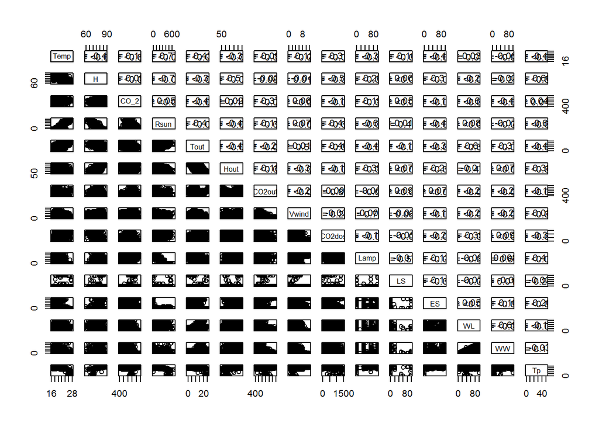

```r
GHdata = read.csv("Data2011.csv")
pairs(GHdata, upper.panel=panel.cor)
```

```r
GHdata_day <- GHdata[GHdata$Rsun>0.3,]
GHdata_night <- GHdata[GHdata$Rsun<=0.3,]
```

## 02: Multiple Linear Model

```r
lm.fit = lm(Temp~.,data=GHdata)
summary(lm.fit)
```

```
##
## Call:
## lm(formula = Temp ~ ., data = GHdata)
##
## Residuals:
##     Min      1Q  Median      3Q     Max
## -4.3306 -0.7635 -0.1045  0.6654  5.6570
##
## Coefficients:
##               Estimate Std. Error t value Pr(>|t|)
## (Intercept)  4.838e+00  8.410e-01   5.752 9.93e-09 ***
## H            1.106e-01  1.146e-02   9.645  < 2e-16 ***
## CO_2         1.083e-03  1.622e-04   6.682 2.93e-11 ***
## Rsun         1.688e-02  3.878e-04  43.530  < 2e-16 ***
## Tout         1.836e-01  8.888e-03  20.658  < 2e-16 ***
## Hout         3.551e-03  2.837e-03   1.251   0.2109
## CO2out       1.306e-03  5.834e-04   2.239   0.0252 *
## Vwind        2.623e-02  1.254e-02   2.092   0.0365 *
## CO2dos      -5.189e-04  7.238e-05  -7.169 1.00e-12 ***
## Lamp         1.832e-02  1.043e-03  17.563  < 2e-16 ***
## LS           2.674e-02  1.778e-03  15.040  < 2e-16 ***
## ES           5.093e-04  7.822e-04   0.651   0.5150
## WL          -8.788e-03  1.567e-03  -5.607 2.29e-08 ***
## WW           7.305e-04  1.445e-03   0.506   0.6132
## Tp           1.301e-02  6.231e-03   2.088   0.0369 *
## ---
## Signif. codes:  0 '***' 0.001 '**' 0.01 '*' 0.05 '.' 0.1 ' ' 1
##
## Residual standard error: 1.093 on 2385 degrees of freedom
## Multiple R-squared:  0.7384, Adjusted R-squared:  0.7369
## F-statistic: 480.8 on 14 and 2385 DF,  p-value: < 2.2e-16
```

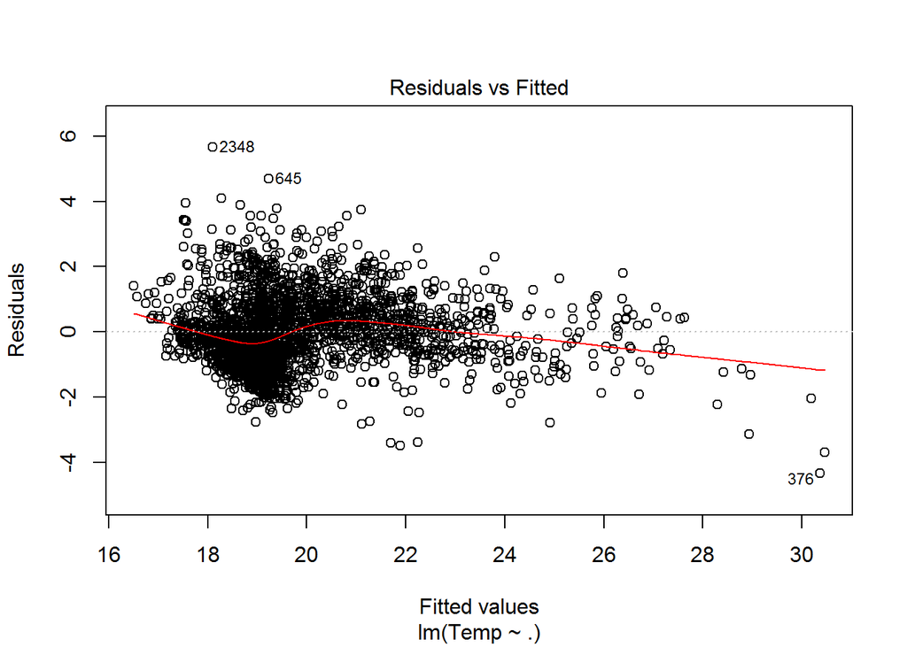

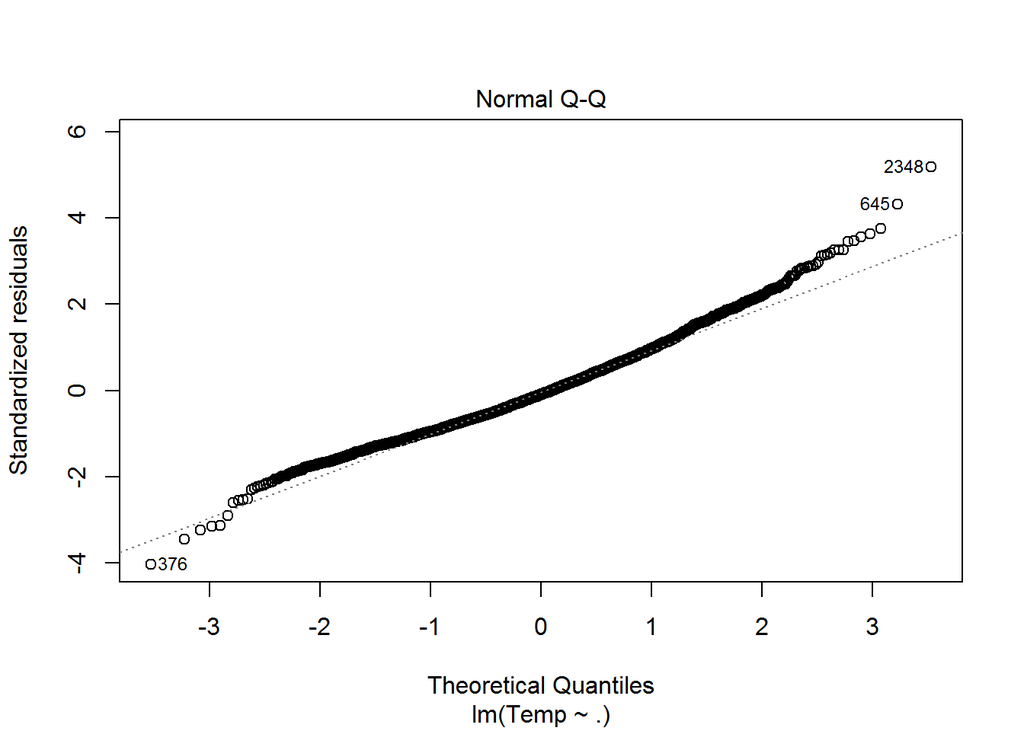

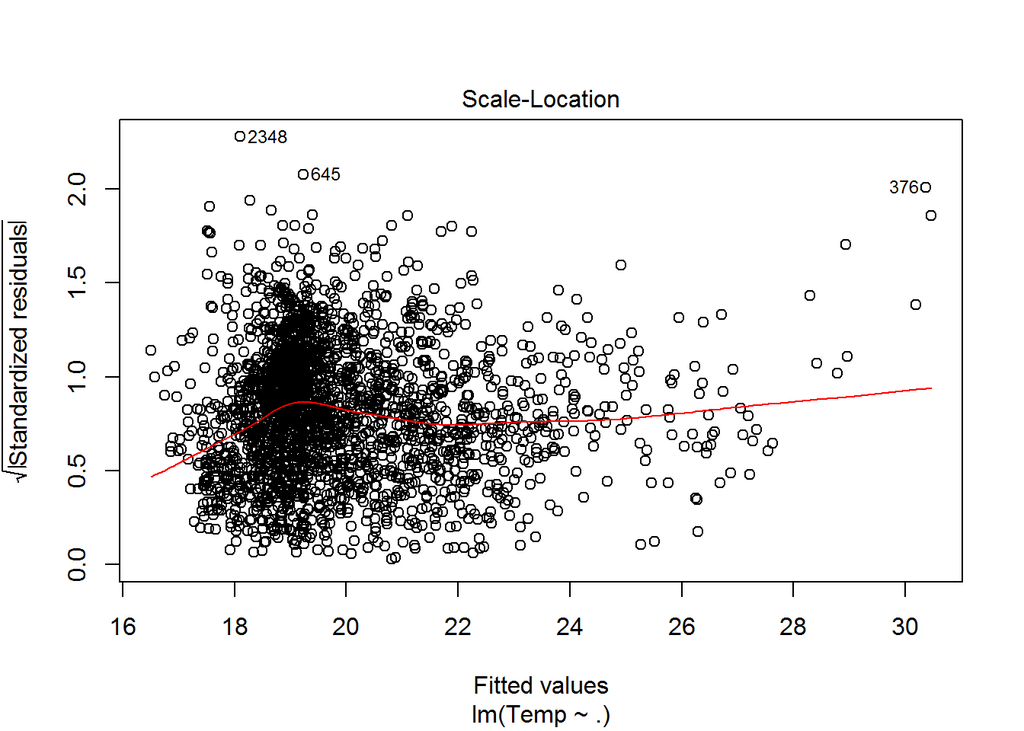

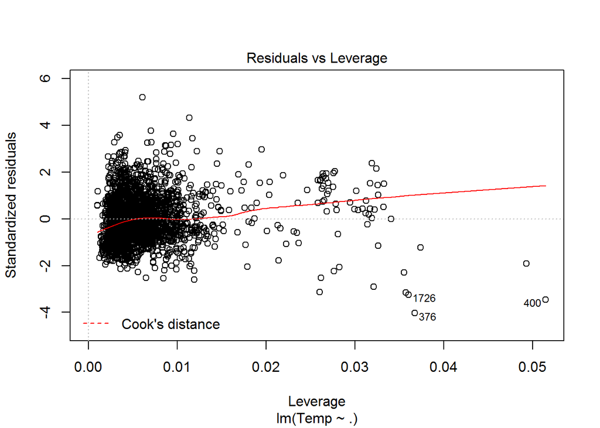

```r
plot(lm.fit)
```

```r
# Extra
#fullmod=lm(Temp ~ H + CO_2 + Rsun + Tout + Hout + CO2out + Vwind + CO2dos + Lamp + LS + ES + WL + WW + Tp , data = GHdata)
#nothing=lm(Temp ~ 1, data=GHdata)
#backwards=step(fullmod, trace=0)
#forwards = step(nothing,scope=list(lower=formula(nothing),upper=formula(fullmod)), direction="forward")

#lm.fit = lm(Temp ~ Rsun + LS + Tout + CO_2 + Lamp + H + CO2dos,data=GHdata)
#plot(lm.fit)
```

**The conditions for Multiple Linear Regression with all variables is not met, because some predictors are not significant, there are some outliers and there is still some unexplained variation causing a non-linear line in the residuals/fitted value plot.**

## 03: ANOVA

```r
summary(lm.fit)
```

```
##
## Call:
## lm(formula = Temp ~ ., data = GHdata)
##
## Residuals:
##     Min      1Q  Median      3Q     Max
## -4.3306 -0.7635 -0.1045  0.6654  5.6570
##
## Coefficients:
##               Estimate Std. Error t value Pr(>|t|)
## (Intercept)  4.838e+00  8.410e-01   5.752 9.93e-09 ***
## H            1.106e-01  1.146e-02   9.645  < 2e-16 ***
## CO_2         1.083e-03  1.622e-04   6.682 2.93e-11 ***
## Rsun         1.688e-02  3.878e-04  43.530  < 2e-16 ***
## Tout         1.836e-01  8.888e-03  20.658  < 2e-16 ***
## Hout         3.551e-03  2.837e-03   1.251   0.2109
## CO2out       1.306e-03  5.834e-04   2.239   0.0252 *
## Vwind        2.623e-02  1.254e-02   2.092   0.0365 *
## CO2dos      -5.189e-04  7.238e-05  -7.169 1.00e-12 ***
## Lamp         1.832e-02  1.043e-03  17.563  < 2e-16 ***
## LS           2.674e-02  1.778e-03  15.040  < 2e-16 ***
## ES           5.093e-04  7.822e-04   0.651   0.5150
## WL          -8.788e-03  1.567e-03  -5.607 2.29e-08 ***
## WW           7.305e-04  1.445e-03   0.506   0.6132
## Tp           1.301e-02  6.231e-03   2.088   0.0369 *
## ---
## Signif. codes:  0 '***' 0.001 '**' 0.01 '*' 0.05 '.' 0.1 ' ' 1
##
## Residual standard error: 1.093 on 2385 degrees of freedom
## Multiple R-squared:  0.7384, Adjusted R-squared:  0.7369
## F-statistic: 480.8 on 14 and 2385 DF,  p-value: < 2.2e-16
```

```r
# Extra
#paste(lm.fit$coefficients,names(lm.fit$coefficients),collapse = "*")
```

**The formula is: Temp ~ H + CO_2 + Rsun + Tout + Hout + CO2out + Vwind + CO2dos + Lamp + LS + ES + WL + WW + Tp. Or in short you can use Temp~. The prediction formula of the response is: Inside Temperature = 4.8376 + 0.1106*H + 0.0011*CO_2+0.0169*Rsun+0.1836*Tout+0.0036*Hout+0.0013*CO20ut+0.0262*Vwind-0.0005*CO2Dos+0.0183*Lamp+0.0267*LS+0.0005*ES-0.0088*WL+0.0007*WW+0.0130*Tp.**

## 04: Remove Non significant variables

```r
lm.fit2=lm(Temp ~ H + CO_2 + Rsun + Tout + CO2out + Vwind + CO2dos + Lamp + LS + WL + Tp , data = GHdata)
summary(lm.fit2)
```

```
##
## Call:
## lm(formula = Temp ~ H + CO_2 + Rsun + Tout + CO2out + Vwind +
##     CO2dos + Lamp + LS + WL + Tp, data = GHdata)
##
## Residuals:
##     Min      1Q  Median      3Q     Max
## -4.3452 -0.7548 -0.1010  0.6728  5.6866
##
## Coefficients:
##               Estimate Std. Error t value Pr(>|t|)
## (Intercept)  4.706e+00  8.250e-01   5.704 1.31e-08 ***
## H            1.174e-01  1.028e-02  11.418  < 2e-16 ***
## CO_2         1.034e-03  1.576e-04   6.558 6.68e-11 ***
## Rsun         1.684e-02  3.666e-04  45.945  < 2e-16 ***
## Tout         1.780e-01  7.730e-03  23.020  < 2e-16 ***
## CO2out       1.411e-03  5.717e-04   2.468   0.0137 *
## Vwind        2.114e-02  1.187e-02   1.780   0.0751 .
## CO2dos      -5.026e-04  6.998e-05  -7.182 9.11e-13 ***
## Lamp         1.851e-02  9.971e-04  18.560  < 2e-16 ***
## LS           2.695e-02  1.757e-03  15.340  < 2e-16 ***
## WL          -7.898e-03  1.316e-03  -6.003 2.24e-09 ***
## Tp           1.182e-02  6.107e-03   1.935   0.0531 .
## ---
## Signif. codes:  0 '***' 0.001 '**' 0.01 '*' 0.05 '.' 0.1 ' ' 1
##
## Residual standard error: 1.093 on 2388 degrees of freedom
## Multiple R-squared:  0.7382, Adjusted R-squared:  0.737
## F-statistic:   612 on 11 and 2388 DF,  p-value: < 2.2e-16
```

```r
relchange <- (as.numeric(lm.fit2$coefficients) - as.numeric(lm.fit$coefficients[c(-6,-12,-14)]))*100/as.numeric(lm.fit$coefficients[c(-6,-12,-14)])
matchange <- as.data.frame(names(lm.fit2$coefficients))
matchange$change <- relchange
sig.val.one <- summary(lm.fit)$coefficients[,4]
sig.val.one <-sig.val.one[c(-6,-12,-14)]
matchange$sig.val.one <- round(sig.val.one,digits = 3)
matchange$sig.val.two <- round(summary(lm.fit2)$coefficients[,4], digits=3)
colnames(matchange) <- c("Names", "Relative Coefficient Change (%)", "Sig.val1", "Sig.val2")
matchange
```

```
##          Names Relative Coefficient Change (%) Sig.val1 Sig.val2
## 1  (Intercept)                      -2.7244888    0.000    0.000
## 2            H                       6.1532776    0.000    0.000
## 3         CO_2                      -4.5978893    0.000    0.000
## 4         Rsun                      -0.2271535    0.000    0.000
## 5         Tout                      -3.0780648    0.000    0.000
## 6       CO2out                       7.9931134    0.025    0.014
## 7        Vwind                     -19.4037072    0.037    0.075
## 8       CO2dos                      -3.1381142    0.000    0.000
## 9         Lamp                       1.0160567    0.000    0.000
## 10          LS                       0.7938320    0.000    0.000
## 11          WL                     -10.1236590    0.000    0.000
## 12          Tp                      -9.1754443    0.037    0.053
```

**Hout, ES and WW were removed from the model. **Vwind**,**TP** and **CO2Out** have a Coefficient in model2 that relatively changed (-19.4%, -9.2% ,8.0% change)a lot from model1. **Vwind**,**Tp** and **CO2out** were not as significant (0.05>p>0.01) as the other predictors (p<0.01). However **WL** had a high significance (p<0.01) and the coefficient relatively changed (-10.1% change) a lot as well. It does surprise us that WL changed so much while it was highly significant.**

## 05: Remove Non significant variables (Cont.)

```r
lm.fit3=lm(Temp ~ H + CO_2 + Rsun + Tout+ CO2dos + Lamp + LS + WL , data = GHdata)
summary(lm.fit3)
```

```
##
## Call:
## lm(formula = Temp ~ H + CO_2 + Rsun + Tout + CO2dos + Lamp +
##     LS + WL, data = GHdata)
##
## Residuals:
##     Min      1Q  Median      3Q     Max
## -4.2128 -0.7649 -0.0927  0.6838  5.7424
##
## Coefficients:
##               Estimate Std. Error t value Pr(>|t|)
## (Intercept)  5.410e+00  7.751e-01   6.981 3.79e-12 ***
## H            1.243e-01  9.447e-03  13.161  < 2e-16 ***
## CO_2         1.076e-03  1.520e-04   7.080 1.88e-12 ***
## Rsun         1.683e-02  3.631e-04  46.339  < 2e-16 ***
## Tout         1.727e-01  7.005e-03  24.657  < 2e-16 ***
## CO2dos      -4.882e-04  6.978e-05  -6.996 3.41e-12 ***
## Lamp         1.854e-02  9.827e-04  18.866  < 2e-16 ***
## LS           2.679e-02  1.752e-03  15.294  < 2e-16 ***
## WL          -8.367e-03  1.206e-03  -6.935 5.19e-12 ***
## ---
## Signif. codes:  0 '***' 0.001 '**' 0.01 '*' 0.05 '.' 0.1 ' ' 1
##
## Residual standard error: 1.094 on 2391 degrees of freedom
## Multiple R-squared:  0.737,  Adjusted R-squared:  0.7361
## F-statistic: 837.5 on 8 and 2391 DF,  p-value: < 2.2e-16
```

## 06: Reloading

```r
rm(list=ls())
GHdata = read.csv("Data2011.csv")

lm.fit = lm(formula = Temp ~ H + CO_2 + Rsun + Tout + CO2out + CO2dos + Lamp + LS + WL + Tp, data = GHdata)

summary(lm.fit)
```

```
##
## Call:
## lm(formula = Temp ~ H + CO_2 + Rsun + Tout + CO2out + CO2dos +
##     Lamp + LS + WL + Tp, data = GHdata)
##
## Residuals:
##     Min      1Q  Median      3Q     Max
## -4.3735 -0.7659 -0.0940  0.6787  5.7805
##
## Coefficients:
##               Estimate Std. Error t value Pr(>|t|)
## (Intercept)  4.9922765  0.8095208   6.167 8.15e-10 ***
## H            0.1154551  0.0102279  11.288  < 2e-16 ***
## CO_2         0.0010200  0.0001575   6.476 1.14e-10 ***
## Rsun         0.0168895  0.0003659  46.157  < 2e-16 ***
## Tout         0.1806556  0.0075832  23.823  < 2e-16 ***
## CO2out       0.0011403  0.0005513   2.068   0.0387 *
## CO2dos      -0.0005049  0.0000700  -7.213 7.32e-13 ***
## Lamp         0.0186145  0.0009957  18.694  < 2e-16 ***
## LS           0.0269289  0.0017578  15.320  < 2e-16 ***
## WL          -0.0087913  0.0012170  -7.224 6.77e-13 ***
## Tp           0.0135298  0.0060339   2.242   0.0250 *
## ---
## Signif. codes:  0 '***' 0.001 '**' 0.01 '*' 0.05 '.' 0.1 ' ' 1
##
## Residual standard error: 1.093 on 2389 degrees of freedom
## Multiple R-squared:  0.7378, Adjusted R-squared:  0.7367
## F-statistic: 672.3 on 10 and 2389 DF,  p-value: < 2.2e-16
```

**Remove WW, ES, Hout and Vwind variables, because they were not significant. The linear model did not decrease in R-squared untill Vwind was removed. The resulting model is: Q6: lm(Temp ~ H + CO_2 + Rsun + Tout + CO2out + CO2dos + Lamp + LS + WL + Tp, data = GHdata) R2 = 0.7367 Q5: lm(Temp ~ H + CO_2 + Rsun + Tout+ CO2dos + Lamp + LS + WL , data = GHdata) R2 = 0.7361 Comparing this model (Q6) to the model of question five we can see that CO2out and TP were removed in question five while they could have stayed in the linear model if one removed one variable at a time. The model of question five has a lower explained variance (R2=0.7361) compared to the model of question six (R2=0.7367). Thus the model of question six seems to be better with a small margin.**

## 07: Pipe Temperature

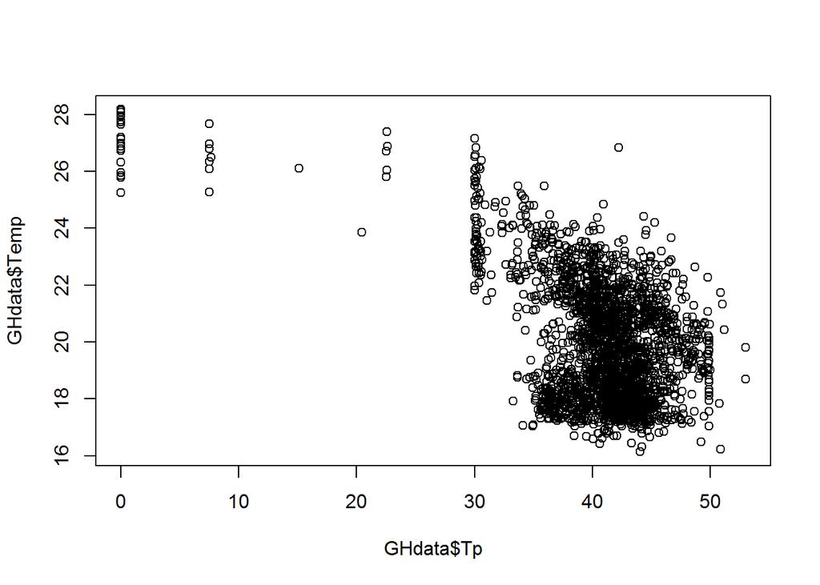

```r
plot(GHdata$Tp,GHdata$Temp)
```

Pipe temperature doesn’t have a very significant influence on air temperature in our dataset, because the grower likes to keep a stable temperature for the plants around 20 degrees. Thus the grower both uses the water to cool down the temperature inside (above 25 C) and to warm the temperature inside (below 17 degrees). The temperature is balanced by the water heater and thus does not change with the temperature inside.

We are not sure about this answer (WE ARE GEOSCIENTISTS)

## 08: Causility Model

### a.

Q6: lm(Temp ~ H + CO_2 + Rsun + Tout + CO2out + CO2dos + Lamp + LS + WL + Tp, data = GHdata) R2 = 0.7367

The assumption behind this model is that all predictors can explain the temperature inside of the green house. In the sense that all predictors cause an effect on temperature inside.

### b.

The assumption regarding the dynamics of the model is that the variables, relative humidity, CO2 inside, Radiation from sun, Temperature Outside, CO2 outside, Artifical Lighting, Opening of light screen, and temperature of pipe to heat exchanger, have a positive effect on the temperature. The CO2 dosage and Windows opening leeward have a negative effect on the temperature.

Causality explained: A higher relative humidity will have a higher heat capacity. Thus the temperature won’t change as quickly if the air is more humid.

Like the theory lying behind the greenhoue effect, more CO2 in this case also stops heat/rediation escape from the greenhouse to outside.

Radiation from sun gives off warmth when it hits the earth surface. Thus radiation from sun should have a positive influence on the temperature inside.

Tempearture outside can influence the temperature inside by the forms of sensible heat.

Like the greenhoue effect, more CO2 outside also stops heat/rediation escape from the earth, reflects it back to the greenhouse and thus keeps the temperature higher.

Artificial lighting should give off heat in the process of making light and thus heat the temperature inside.

Opening the light screen more will let more sun radiation in and thus will give a higher temperature inside the greenhouse.

The temperature from the pipes heats up the greenhouse.

Opening the windows on the leeward side will allow temperature from inside and outside to mix more.

After a long discussion, we thought the predictors were realistic.

## 09: Improving model

```r
rm(list=ls())
GHdata = read.csv("Data2011.csv")
lm.fit0 = lm(formula = Temp ~ H + CO_2 + Rsun + Tout + CO2out + CO2dos + Lamp + LS + WL + Tp, data = GHdata)
lm.fit1 = lm(formula = Temp ~ H + CO_2 + Rsun + Tout + CO2out + CO2dos + Lamp + LS + WL + Tp + Vwind +I(CO_2*Rsun)+I(CO2out*Rsun)+I(CO2dos*Rsun)+I(Vwind*WL)+I(Vwind*Tout), data = GHdata)




lm.fit2 = lm(formula = (Temp**8) ~ H + CO_2 + Rsun + Tout + CO2out + CO2dos + Lamp + LS + WL + Tp + Vwind +I(CO_2*Rsun)+I(CO2out*Rsun)+I(CO2dos*Rsun)+I(Vwind*WL)+I(Vwind*Tout), data = GHdata)

summary(lm.fit0)
```

```
##
## Call:
## lm(formula = Temp ~ H + CO_2 + Rsun + Tout + CO2out + CO2dos +
##     Lamp + LS + WL + Tp, data = GHdata)
##
## Residuals:
##     Min      1Q  Median      3Q     Max
## -4.3735 -0.7659 -0.0940  0.6787  5.7805
##
## Coefficients:
##               Estimate Std. Error t value Pr(>|t|)
## (Intercept)  4.9922765  0.8095208   6.167 8.15e-10 ***
## H            0.1154551  0.0102279  11.288  < 2e-16 ***
## CO_2         0.0010200  0.0001575   6.476 1.14e-10 ***
## Rsun         0.0168895  0.0003659  46.157  < 2e-16 ***
## Tout         0.1806556  0.0075832  23.823  < 2e-16 ***
## CO2out       0.0011403  0.0005513   2.068   0.0387 *
## CO2dos      -0.0005049  0.0000700  -7.213 7.32e-13 ***
## Lamp         0.0186145  0.0009957  18.694  < 2e-16 ***
## LS           0.0269289  0.0017578  15.320  < 2e-16 ***
## WL          -0.0087913  0.0012170  -7.224 6.77e-13 ***
## Tp           0.0135298  0.0060339   2.242   0.0250 *
## ---
## Signif. codes:  0 '***' 0.001 '**' 0.01 '*' 0.05 '.' 0.1 ' ' 1
##
## Residual standard error: 1.093 on 2389 degrees of freedom
## Multiple R-squared:  0.7378, Adjusted R-squared:  0.7367
## F-statistic: 672.3 on 10 and 2389 DF,  p-value: < 2.2e-16
```

```r
summary(lm.fit1)
```

```
##
## Call:
## lm(formula = Temp ~ H + CO_2 + Rsun + Tout + CO2out + CO2dos +
##     Lamp + LS + WL + Tp + Vwind + I(CO_2 * Rsun) + I(CO2out *
##     Rsun) + I(CO2dos * Rsun) + I(Vwind * WL) + I(Vwind * Tout),
##     data = GHdata)
##
## Residuals:
##     Min      1Q  Median      3Q     Max
## -4.5800 -0.7760 -0.0862  0.6561  5.4169
##
## Coefficients:
##                    Estimate Std. Error t value Pr(>|t|)
## (Intercept)       4.990e+00  8.625e-01   5.786 8.17e-09 ***
## H                 1.145e-01  1.067e-02  10.734  < 2e-16 ***
## CO_2              9.934e-04  1.663e-04   5.973 2.68e-09 ***
## Rsun              1.276e-02  2.229e-03   5.724 1.17e-08 ***
## Tout              2.016e-01  1.303e-02  15.470  < 2e-16 ***
## CO2out            9.659e-04  6.556e-04   1.473  0.14078
## CO2dos           -4.548e-04  8.156e-05  -5.576 2.74e-08 ***
## Lamp              1.823e-02  1.032e-03  17.665  < 2e-16 ***
## LS                2.674e-02  1.755e-03  15.235  < 2e-16 ***
## WL               -1.415e-02  2.060e-03  -6.871 8.09e-12 ***
## Tp                1.441e-02  6.640e-03   2.169  0.03015 *
## Vwind             6.484e-02  2.887e-02   2.246  0.02482 *
## I(CO_2 * Rsun)    2.602e-06  1.470e-06   1.770  0.07683 .
## I(CO2out * Rsun)  3.678e-06  4.485e-06   0.820  0.41226
## I(CO2dos * Rsun) -2.226e-07  5.144e-07  -0.433  0.66534
## I(Vwind * WL)     2.209e-03  5.377e-04   4.108 4.12e-05 ***
## I(Vwind * Tout)  -9.001e-03  3.336e-03  -2.698  0.00702 **
## ---
## Signif. codes:  0 '***' 0.001 '**' 0.01 '*' 0.05 '.' 0.1 ' ' 1
##
## Residual standard error: 1.088 on 2383 degrees of freedom
## Multiple R-squared:  0.7408, Adjusted R-squared:  0.7391
## F-statistic: 425.8 on 16 and 2383 DF,  p-value: < 2.2e-16
```

```r
summary(lm.fit2)
```

```
##
## Call:
## lm(formula = (Temp^8) ~ H + CO_2 + Rsun + Tout + CO2out + CO2dos +
##     Lamp + LS + WL + Tp + Vwind + I(CO_2 * Rsun) + I(CO2out *
##     Rsun) + I(CO2dos * Rsun) + I(Vwind * WL) + I(Vwind * Tout),
##     data = GHdata)
##
## Residuals:
##        Min         1Q     Median         3Q        Max
## -8.866e+10 -8.639e+09 -1.751e+09  6.472e+09  1.705e+11
##
## Coefficients:
##                    Estimate Std. Error t value Pr(>|t|)
## (Intercept)      -1.663e+11  1.374e+10 -12.103  < 2e-16 ***
## H                 2.925e+09  1.700e+08  17.207  < 2e-16 ***
## CO_2              4.917e+06  2.650e+06   1.856  0.06361 .
## Rsun             -5.839e+07  3.552e+07  -1.644  0.10027
## Tout              3.055e+09  2.076e+08  14.716  < 2e-16 ***
## CO2out           -8.320e+06  1.044e+07  -0.797  0.42571
## CO2dos           -1.091e+07  1.299e+06  -8.394  < 2e-16 ***
## Lamp              2.872e+08  1.644e+07  17.469  < 2e-16 ***
## LS                4.498e+08  2.796e+07  16.087  < 2e-16 ***
## WL               -2.744e+08  3.281e+07  -8.362  < 2e-16 ***
## Tp               -2.084e+09  1.058e+08 -19.699  < 2e-16 ***
## Vwind             1.443e+09  4.600e+08   3.137  0.00173 **
## I(CO_2 * Rsun)   -1.283e+05  2.342e+04  -5.480 4.71e-08 ***
## I(CO2out * Rsun)  8.949e+05  7.146e+04  12.524  < 2e-16 ***
## I(CO2dos * Rsun)  3.585e+04  8.196e+03   4.374 1.27e-05 ***
## I(Vwind * WL)     3.995e+07  8.566e+06   4.664 3.28e-06 ***
## I(Vwind * Tout)  -2.592e+08  5.314e+07  -4.877 1.15e-06 ***
## ---
## Signif. codes:  0 '***' 0.001 '**' 0.01 '*' 0.05 '.' 0.1 ' ' 1
##
## Residual standard error: 1.734e+10 on 2383 degrees of freedom
## Multiple R-squared:  0.8306, Adjusted R-squared:  0.8295
## F-statistic: 730.5 on 16 and 2383 DF,  p-value: < 2.2e-16
```

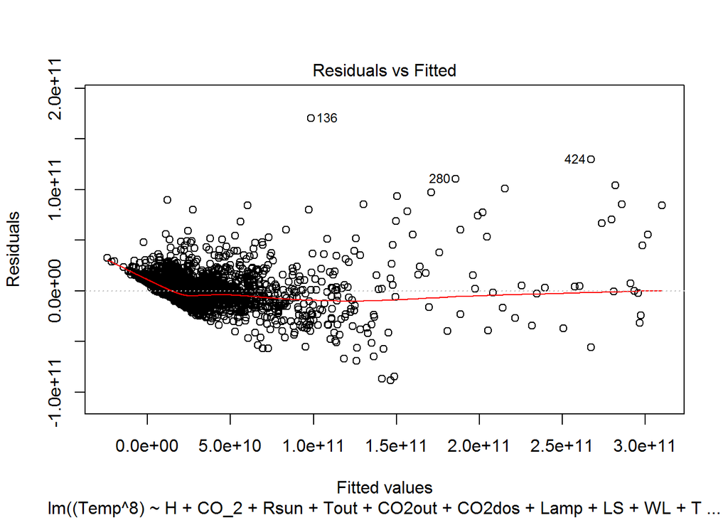

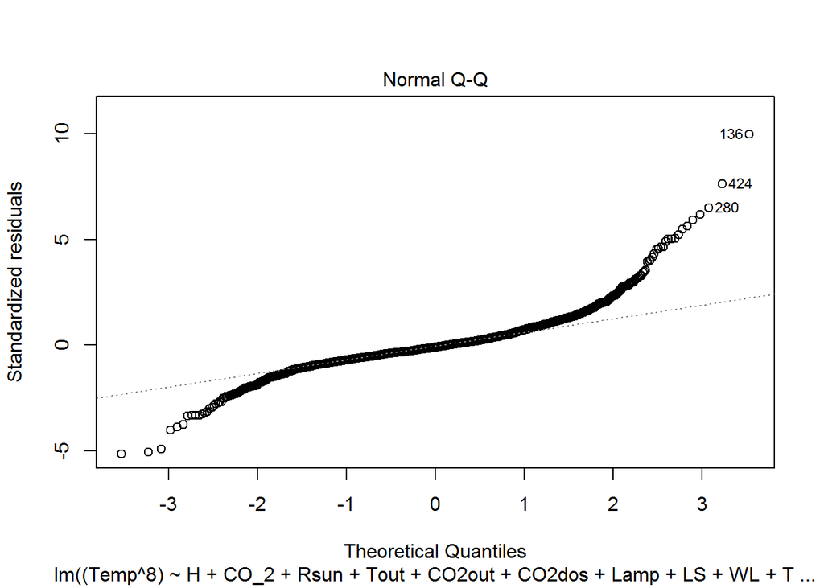

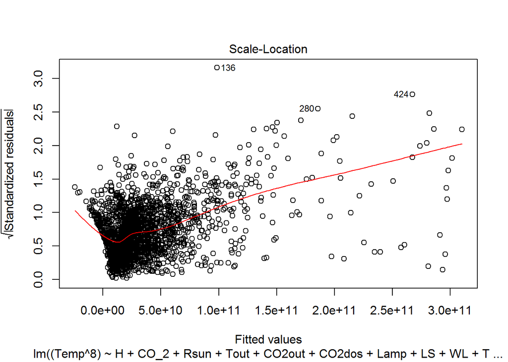

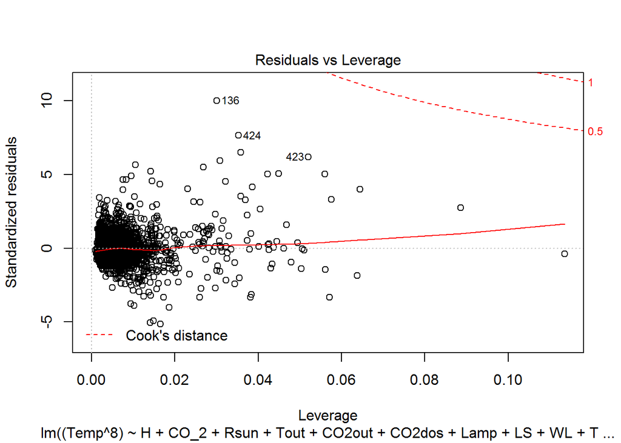

```r
plot(lm.fit2)
```

```r
for (value in 1:100){
  lm.fit2 = lm(formula = (Temp**value) ~ H + CO_2 + Rsun + Tout + CO2out + CO2dos + Lamp + LS + WL + Tp + Vwind +I(CO_2*Rsun)+I(CO2out*Rsun)+I(CO2dos*Rsun)+I(Vwind*WL)+I(Vwind*Tout), data = GHdata)
  print(paste(value,"=",summary(lm.fit2)$r.squared))
}
```

```
## [1] "1 = 0.740848029712654"
## [1] "2 = 0.765380040356797"
## [1] "3 = 0.787459416621593"
## [1] "4 = 0.806019082941289"
## [1] "5 = 0.820097597742152"
## [1] "6 = 0.829007254877812"
## [1] "7 = 0.832465732000395"
## [1] "8 = 0.830642395572273"
## [1] "9 = 0.824102172541345"
## [1] "10 = 0.81367190722555"
## [1] "11 = 0.800280240815557"
## [1] "12 = 0.784819804437108"
## [1] "13 = 0.768058406018385"
## [1] "14 = 0.750601434789192"
## [1] "15 = 0.732892684776717"
```

[output cut: 85 more lines]

lm.fit2 = lm(formula = (Temp**7) ~ H + CO_2 + Rsun + Tout + CO2out + CO2dos + Lamp + LS + WL + Tp + Vwind +I(CO_2*Rsun)+I(CO2out*Rsun)+I(CO2dos*Rsun)+I(Vwind*WL)+I(Vwind*Tout), data = GHdata) has a Rsquare of 0.832465732000395

## 10: Benefits model

This model can help the grower to see which variables have the biggest effect on the temperature in which direction. Thus the grower has better control over his green house ecosystem in terms of energy and optimal environment for plant growth. If cost is linked to these benefits per unit as well. The grower can see which variables can be used most cost-effectively to regulate the temperature inside the greenhouse. On operability of this system. Sensors are already used to measure these inputs and control systems can regulate things. The can model can together with these sensors and control systems easily create an optimal environment for the plants with enough warmth.

## 11: Warning Model Preparation

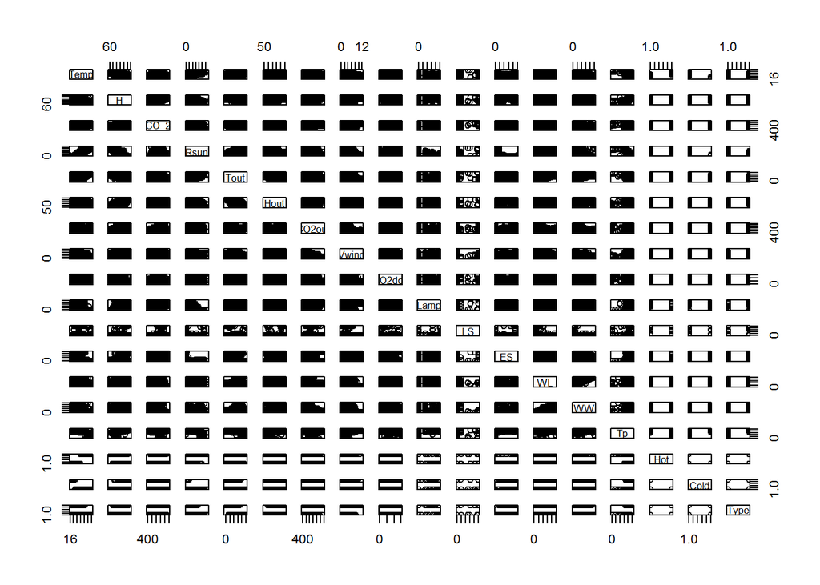

```r
data2 = read.csv("Data2011_2.csv")
plot(data2)
```

```r
summary(data2)
```

```
##       Temp             H              CO_2             Rsun
##  Min.   :16.14   Min.   :58.99   Min.   : 394.5   Min.   :  0.00
##  1st Qu.:18.10   1st Qu.:76.54   1st Qu.: 817.5   1st Qu.:  0.30
##  Median :19.47   Median :78.92   Median : 992.5   Median :  0.40
##  Mean   :19.89   Mean   :78.25   Mean   : 936.2   Mean   : 64.30
##  3rd Qu.:21.29   3rd Qu.:80.65   3rd Qu.:1086.1   3rd Qu.: 64.25
##  Max.   :28.18   Max.   :89.29   Max.   :1392.0   Max.   :672.50
##       Tout            Hout            CO2out          Vwind
##  Min.   :-1.10   Min.   : 48.60   Min.   :396.1   Min.   : 0.000
##  1st Qu.: 6.50   1st Qu.: 75.30   1st Qu.:443.8   1st Qu.: 1.900
##  Median :10.10   Median : 85.90   Median :465.7   Median : 3.300
##  Mean   :10.41   Mean   : 83.66   Mean   :475.2   Mean   : 3.606
##  3rd Qu.:14.10   3rd Qu.: 93.20   3rd Qu.:495.0   3rd Qu.: 5.000
##  Max.   :25.80   Max.   :100.00   Max.   :698.9   Max.   :12.200
##      CO2dos            Lamp              LS                ES
##  Min.   :   0.0   Min.   :  0.00   Min.   :  0.000   Min.   :  0.00
##  1st Qu.:   0.0   1st Qu.: 66.70   1st Qu.:  0.000   1st Qu.:  0.00
##  Median : 380.6   Median : 66.70   Median :  0.000   Median : 30.00
##  Mean   : 470.8   Mean   : 69.53   Mean   :  1.814   Mean   : 32.99
##  3rd Qu.: 781.7   3rd Qu.:100.00   3rd Qu.:  0.000   3rd Qu.: 75.01
##  Max.   :1500.0   Max.   :100.00   Max.   :100.000   Max.   :100.00
##        WL                WW                Tp         Hot        Cold
##  Min.   :  1.087   Min.   :  0.000   Min.   : 0.00   no :2008   no :1362
##  1st Qu.:  6.306   1st Qu.:  0.000   1st Qu.:39.17   yes: 392   yes:1038
##  Median : 18.312   Median :  2.087   Median :41.56
##  Mean   : 29.256   Mean   : 11.413   Mean   :40.82
##  3rd Qu.: 42.156   3rd Qu.:  9.578   3rd Qu.:43.58
##  Max.   :100.000   Max.   :100.000   Max.   :53.00
##     Type
##  Test :1198
##  Train:1202
##
##
##
##
```